### Installation

You can install:

- the latest development version from GitHub with

  ```r
  install.packages("devtools")
  devtools::install_github("ryanburge/blocks/building")
  ```

### There are just a handful of functions to building right now

## Counting Things

I love the functionality of tabyl, but it doesn’t take a weight variable. Here’s the simple version `ct()`

```r
library(tidyverse)
library(building)
cces <- read_csv("https://raw.githubusercontent.com/ryanburge/blocks/master/cces.csv")

cces %>%
  ct(race)
```

```
#> # A tibble: 8 x 3
#>    race     n   pct
#>   <int> <int> <dbl>
#> 1     1   368 0.736
#> 2     2    54 0.108
#> 3     3    38 0.076
#> 4     4    13 0.026
#> 5     5     7 0.014
#> 6     6     9 0.018
#> 7     7     8 0.016
#> 8     8     3 0.006
```

Note that you are presented with a count column and a pct column.

Let’s add weights

```r
cces %>%
  ct(race, commonweight_vv)
```

```
#> # A tibble: 8 x 3
#>    race       n   pct
#>   <int>   <dbl> <dbl>
#> 1     1 348.    0.758
#> 2     2  43.9   0.096
#> 3     3  34.0   0.074
#> 4     4   7.09  0.015
#> 5     5   3.87  0.008
#> 6     6  15.2   0.033
#> 7     7   6.33  0.014
#> 8     8   0.704 0.002
```

Notice that it’s pipeable. And if you don’t include the weight variable then it won’t be calculated with a weight.

## Getting Confidence Intervals

Oftentimes in social science we like to see what our 95% confidence intervals are, but that’s a lot of syntax. It’s easy with the `mean_ci` function

```r
cces %>%
  mean_ci(gender)
```

```
#> # A tibble: 1 x 7
#>    mean    sd     n level     se lower upper
#>   <dbl> <dbl> <int> <dbl>  <dbl> <dbl> <dbl>
#> 1  1.54 0.499   500  0.05 0.0223  1.49  1.58
```

The default is a 95% confidence interval. However that can be changed easily.

```r
cces %>%
  mean_ci(gender, ci = .84)
```

```
#> # A tibble: 1 x 7
#>    mean    sd     n level     se lower upper
#>   <dbl> <dbl> <int> <dbl>  <dbl> <dbl> <dbl>
#> 1  1.54 0.499   500  0.16 0.0223  1.50  1.57
```

## Simple Mean and Median

I wanted a simple function to calculate the mean and the median. It takes just one variable and computes both statistics.

```r
money1 <- read_csv("https://raw.githubusercontent.com/ryanburge/pls2003_sp17/master/sal_work.csv")

money1
```

```
#> # A tibble: 1,025 x 3
#>       X1 salary names
#>    <int>  <int> <chr>
#>  1     1  14736 Darin Casem
#>  2     2  21261 Jaelyn Groesbeck
#>  3     3  16831 Theodis Butler
#>  4     4  34400 Joewid Rettig
#>  5     5  31239 Breianna Gilbert
#>  6     6  51580 Marcus Gray II
#>  7     7  49699 Berenice Garcia
#>  8     8  66805 Elijah Garrett
#>  9     9  49321 Jeremiah Bishop Jr
#> 10    10  67126 Sultana al-Jabbour
#> # ... with 1,015 more rows
```

```r
money1  %>%
  mean_med(salary)
```

```
#> # A tibble: 1 x 2
#>       mean median
#>      <dbl>  <int>
#> 1 1247953.  35853
```

## Two Value Correlations

Here’s a simple function that generates a pearson correlation of two variables with a p-value.

```r
x <- c(1, 2, 3, 7, 5, 777, 6, 411, 8)
y <- c(11, 23, 1, 4, 6, 22455, 34, 22, 22)
z <- c(34, 3, 21, 4555, 75, 2, 3334, 1122, 22312)

test <- data.frame(x,y,z) %>% as.tibble()

test %>%
  filter(z > 10) %>%
  corr(x,y)
```

[output not shown]

```r
x <- c(1, 2, 3, NA, 5, NA, 6, NA, 8)
y <- c(11, 23, NA, 4, 6, NA, NA, NA, 22)

df <- data.frame(x,y) %>% as.tibble()

df
```

```
#> # A tibble: 9 x 2
#>       x     y
#>   <dbl> <dbl>
#> 1     1    11
#> 2     2    23
#> 3     3    NA
#> 4    NA     4
#> 5     5     6
#> 6    NA    NA
#> 7     6    NA
#> 8    NA    NA
#> 9     8    22
```

```r
na_zero(df, y)
```

```
#> # A tibble: 9 x 2
#>       x     y
#>   <dbl> <dbl>
#> 1     1    11
#> 2     2    23
#> 3     3     0
#> 4    NA     4
#> 5     5     6
#> 6    NA     0
#> 7     6     0
#> 8    NA     0
#> 9     8    22
```

## Making a quick visualization of a bar chart

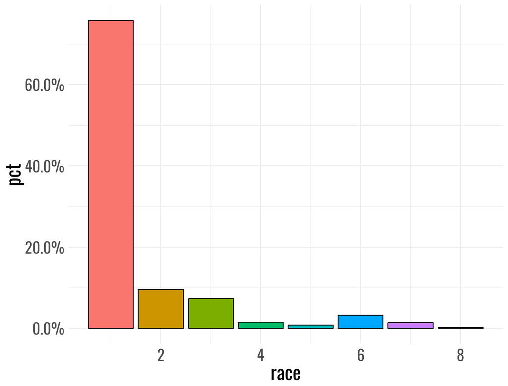

```r
a1 <- cces %>%
  ct(race, commonweight_vv)

gg_col(a1, race, pct)
```

You can easily add the percentages to the top of the bars

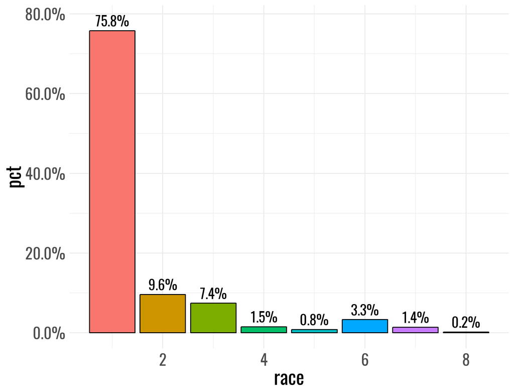

```r
gg_col(a1, race, pct, add_labels = TRUE)
```

And you can change the font by using a font style that is available on [Google Fonts](https://fonts.google.com)

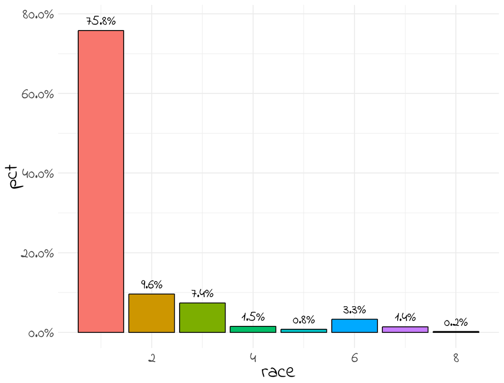

```r
gg_col(a1, race, pct, "Indie Flower", add_labels = TRUE)
```

- let me know what you think on twitter [@ryanburge](https://twitter.com/ryanburge)